# Text Analysis

Jessica Witte

2024-06-08

## Install and Load the required Libraries

Below is the list of the packages that are needed for this class. Remember that if you are working on your machine you only need to install the packages once, but need to upload them every time that you open a new RStudio environment. If you are working on Noteable, you will have to install the packages every time you open the environment.

For Noteable

For Posit

Import the packages:

```r
library(quanteda) #quanteda is an R package for managing and analysing text
library(quanteda.textplots)#Plotting functions for visualising textual data. Extends 'quanteda' and related packages with plot methods designed specifically for text data
library(quanteda.textmodels)#Scaling models and classifiers for sparse matrix objects representing textual data in the form of a document-feature matrix.
library(lexicon)#A collection of lexical hash tables, dictionaries, and word lists
library(tidyverse)# The tidyverse is a collection of R packages designed for data science. All packages share an underlying design philosophy, grammar, and data structures.https://www.tidyverse.org/
```

## Import the Dataset

The first thing we need to do is to load the cleaned data set that we created yesterday

```r
Parish<-read_csv("data/parish.csv")
```

## Exploring the Dataset

Let’s review what’s in our dataset:

```r
summary(Parish)
```

```
##     title               text               Type           TypeDescriptive
##  Length:27065       Length:27065       Length:27065       Length:27065
##  Class :character   Class :character   Class :character   Class :character
##  Mode  :character   Mode  :character   Mode  :character   Mode  :character
##    RecordID             Area              Parish
##  Length:27065       Length:27065       Length:27065
##  Class :character   Class :character   Class :character
##  Mode  :character   Mode  :character   Mode  :character
```

Because we are working with a fully textual dataset, these metrics don’t tell us much. To explore the text itself, we’ll need to create a corpus out of the text column (that contains the text of each parish report)

```r
CorpusStat<-corpus(Parish$text)
```

Some methods for extracting information about the corpus:

```r
summary(CorpusStat, 5)
```

```
## Corpus consisting of 27065 documents, showing 5 documents:
##
##   Text Types Tokens Sentences
##  text1    94    171         1
##  text2   167    399         1
##  text3   123    204         1
##  text4   125    265         1
##  text5   145    285         1
```

Check how many docs are in the corpus

```r
ndoc(CorpusStat)
```

```
## [1] 27065
```

Check number of characters in the first 10 documents of the corpus

```r
nchar(CorpusStat[1:10])
```

```
##  text1  text2  text3  text4  text5  text6  text7  text8  text9 text10
##    940   1906   1011   1245   1354   1422   1995   1916   1855   1977
```

Check number of tokens in the first 10 documents

```r
ntoken(CorpusStat[1:10])
```

```
##  text1  text2  text3  text4  text5  text6  text7  text8  text9 text10
##    171    399    204    265    285    281    422    393    368    457
```

Create a new vector with tokens for all articles and store the vector as a new data frame with four columns (Ntoken, title, Area, Parish)

```r
NtokenStats<-as.vector(ntoken(CorpusStat))
TokenScotland <-data.frame(Tokens=NtokenStats, title=Parish$title, Area=Parish$Area, Parish=Parish$Parish)
```

Now, we want to explore the parish data by geographic area. We can do that with pipes, which allow us to perform several tasks in one block of code:

```r
BreakoutScotland<- TokenScotland %>%
  group_by(Area)%>%
  summarize(NReports=n(), MeanTokens=round(mean(Tokens)))

summary(BreakoutScotland)
```

```
##      Area              NReports        MeanTokens
##  Length:33          Min.   :  84.0   Min.   :417.0
##  Class :character   1st Qu.: 360.0   1st Qu.:434.0
##  Mode  :character   Median : 676.0   Median :442.0
##                     Mean   : 820.2   Mean   :442.2
##                     3rd Qu.:1091.0   3rd Qu.:446.0
##                     Max.   :2622.0   Max.   :476.0
```

We can now plot the trends using gpplot:

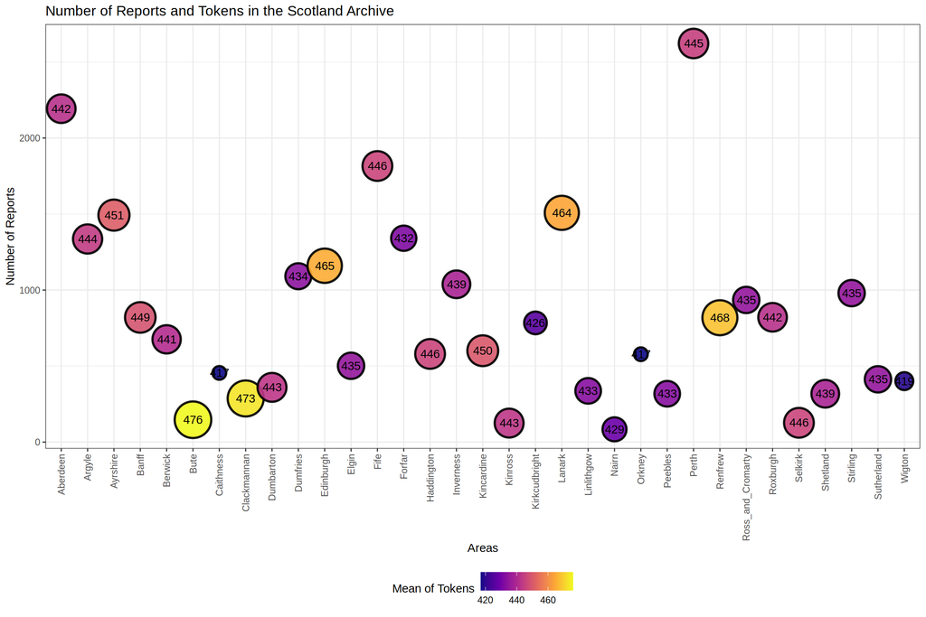

```r
ggplot(BreakoutScotland, aes(x=Area, y=NReports))+ # Select data set and coordinates we are going to plot
  geom_point(aes(size=MeanTokens, fill=MeanTokens),shape=21, stroke=1.5, alpha=0.9, colour="black")+ # Type of graph I want
  labs(x = "Areas", y = "Number of Reports", fill = "Mean of Tokens", size="Mean of Tokens", title="Number of Reports and Tokens in the Scotland Archive")+ # Rename x/y labels and title
  scale_size_continuous(range = c(5, 15))+ # Resize the dots (enlarge)
  geom_text(aes(label=MeanTokens))+ # Add the mean of tokens in the dots
  scale_fill_viridis_c(option = "plasma")+ # Change the colour coding
  theme_bw()+ # B/W Background
  theme(axis.text.x = element_text(angle = 90, vjust = 0.5, hjust = 1), legend.position = "bottom")+ # Rotate x-axis labels and move them slightly down; move legend to the bottom
  guides(size = "none") # Remove the size from the legend
```

## Discussion

What is the graph telling us about our data?

## Preparing your Data for Text Analysis

Now, we can tokenise the corpus, which will break the textual data into separate words grouped by document. We are also remove symbols, URLs, and punctuation.

```r
Report_tokens <- quanteda::tokens(Parish$text,
                                  remove_symbols=TRUE,
                                  remove_url=TRUE,
                                  remove_punct=TRUE,
                                  remove_numbers = FALSE,
                                  split_hyphens = TRUE)
```

Take a look at our tokens list by printing the second document:

```r
Report_tokens[2]
```

```
## Tokens consisting of 1 document.
## text2 :
##  [1] "statistical" "account"     "sown"        "in"          "the"
##  [6] "ground"      "immediately" "surrounding" "the"         "town"
## [11] "of"          "jedburgh"
## [ ... and 333 more ]
```

Remove tokens under 3 characters. (Shorter words won’t tell us much about our data, and because we removed punctuation, we want to get rid of the truncated contractions–e.g. I’m –>‘I’, ‘m’)

```r
Report_tokens <- tokens_select(Report_tokens, min_nchar = 3)
```

```r
Report_tokens <-tokens_remove(Report_tokens, c(stopwords("english"), "statistical", "account", "parish", "one", "years"))
```

## Visualise the Results of the Tokenisation

First I need to convert to document-feature matrix (aka “dfm”)

```r
dfm_Report <- dfm(Report_tokens)
```

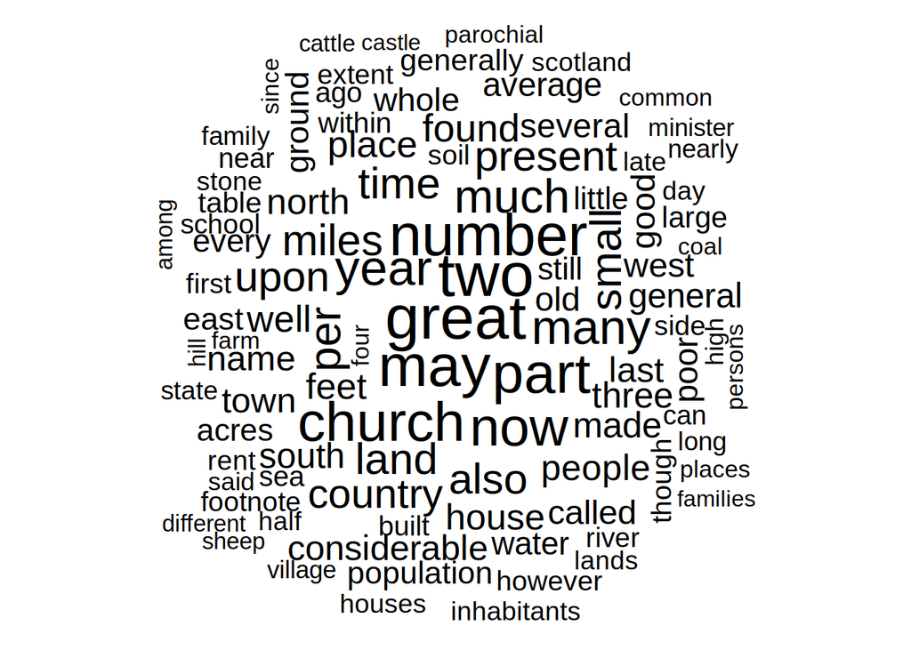

```r
textplot_wordcloud(dfm_Report,
                   max_words=100,
                   color='black')
```

Let’s improve the word cloud a bit

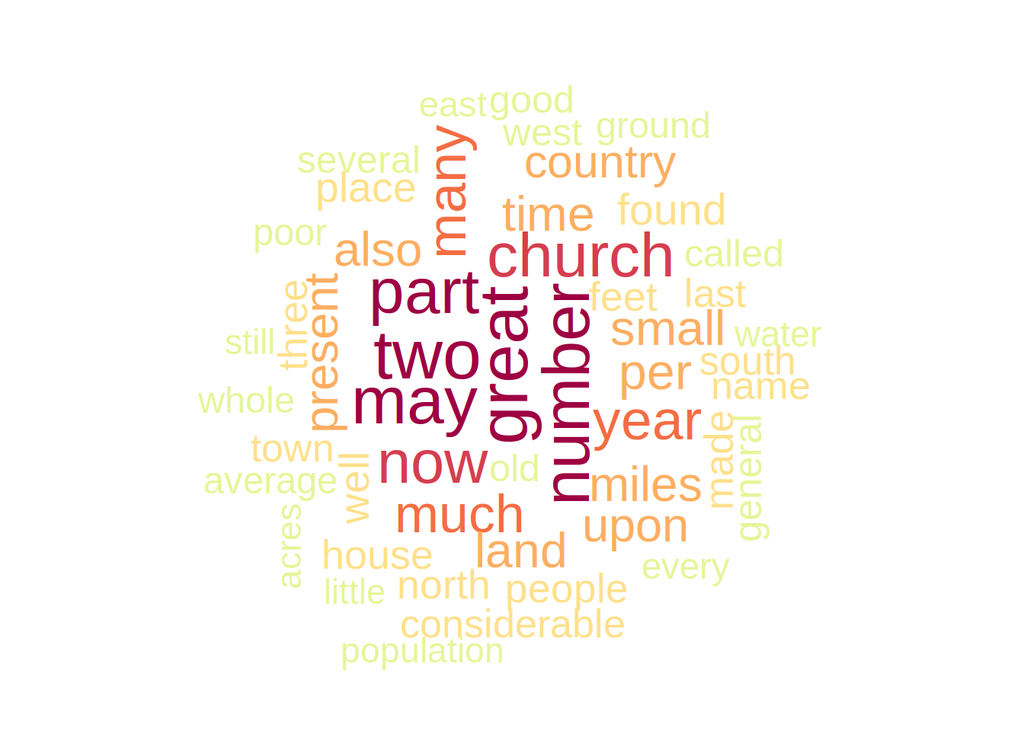

```r
textplot_wordcloud(dfm_Report, rotation = 0.25,
                   max_words=50,
                   color = rev(RColorBrewer::brewer.pal(10, "Spectral")))#adding some colour and rotating results
```

## Further Cleaning the Dataset

Preprocessing steps known as stemming and lemmatisation may further improve the results of NLP for a dataset. Stemming aims to reduce a word to its “stem” in acknowledgment that word endings often don’t tell us much about a particular corpus. So, for instance, stemming assumes “run” and “running” serve the same purposes for a particular research question. Lemmatisation follows the same logic behind stemming, but aims to be more accurate and truer to the language.

Stemming

```r
nostop_toks <- tokens_select(Report_tokens, pattern = stopwords("en"), selection = "remove")
stem_toks <- tokens_wordstem(nostop_toks, language=quanteda_options('language_stemmer'))
stem_dfm <- dfm(stem_toks)
topfeatures(stem_dfm, 30)# Let's see the top 30 words past stemming
```

```
##     part    great     land   number      two     year      may   church
##    25361    21890    20214    19964    19332    19166    18450    18211
##    place  general     hous     mile     time      now     mani  present
##    18050    17895    17147    17029    16847    16447    14696    14436
##     much     near      per    small     name     also      acr     upon
##    14080    13841    13281    13153    12759    12656    12596    12587
##  countri   ground consider   famili    found     farm
##    12412    12135    12074    12008    12007    11773
```

### Lemmatisation

```r
lemmas <- tokens_replace(nostop_toks, pattern = lexicon::hash_lemmas$token, replacement = lexicon::hash_lemmas$lemma)
lemma_dfm <- dfm(lemmas)
topfeatures(lemma_dfm, 30)
```

```
##    good   great     may    part    land     two  church    numb   place   house
##   26731   25816   23232   22608   20202   19332   18199   18178   18049   17132
##    mile    time     now    make    year    many   small present    much    find
##   17005   16830   16442   15955   14939   14691   14449   14156   14077   13623
##     per    also  little    acre    upon    name country  family    foot    farm
##   13269   12656   12617   12591   12575   12453   12373   11987   11972   11754
```

Compare the results

```r
topfeatures(stem_dfm, 20)
```

```
##    part   great    land  number     two    year     may  church   place general
##   25361   21890   20214   19964   19332   19166   18450   18211   18050   17895
##    hous    mile    time     now    mani present    much    near     per   small
##   17147   17029   16847   16447   14696   14436   14080   13841   13281   13153
```

```r
topfeatures(lemma_dfm, 20)
```

```
##    good   great     may    part    land     two  church    numb   place   house
##   26731   25816   23232   22608   20202   19332   18199   18178   18049   17132
##    mile    time     now    make    year    many   small present    much    find
##   17005   16830   16442   15955   14939   14691   14449   14156   14077   13623
```

## Discussion 2

What can we observe about stemming and lemmatization? Which method (if any) do you prefer, and why?

Make a word cloud of the lemmatized results:

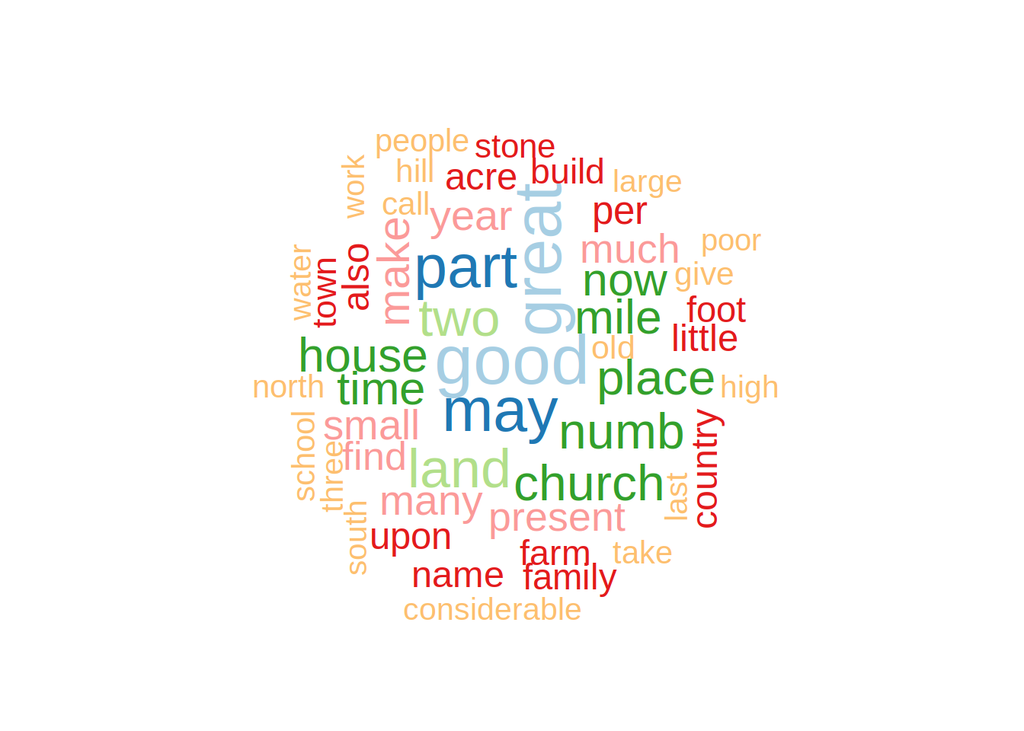

```r
textplot_wordcloud(lemma_dfm, rotation = 0.25,
                   max_words=50,
                   color = rev(RColorBrewer::brewer.pal(10, "Paired")))
```

## Plot the Frequency of Words

Plot the top 20 words (lemmatized) in another way:

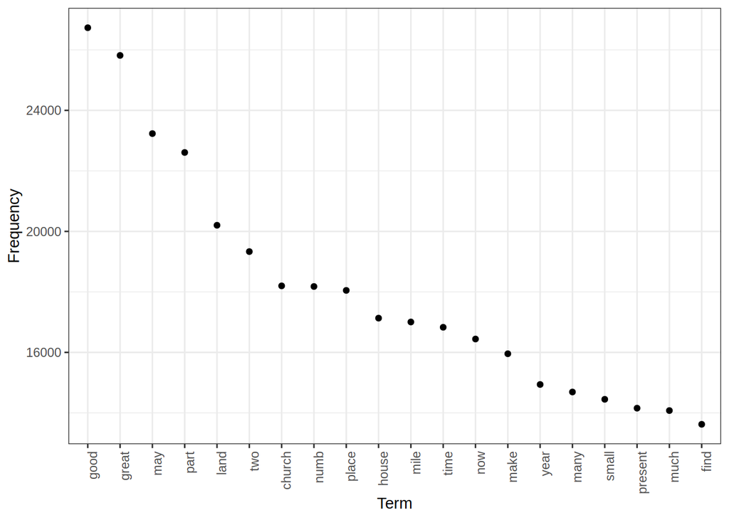

```r
top_keys <- topfeatures (lemma_dfm, 20)
data.frame(list(term = names(top_keys), frequency = unname(top_keys))) %>% # Create a data.frame for ggplot
  ggplot(aes(x = reorder(term,-frequency), y = frequency)) + # Plotting with ggplot2
  geom_point() +
  theme_bw() +
  labs(x = "Term", y = "Frequency") +
  theme(axis.text.x=element_text(angle=90, hjust=1))
```

## Keywords in Context

keyword search examples (using kwic aka “keyword in context”) Let’s search what is around words connected with whisky production and consuption

```r
Whisky<-kwic(Report_tokens , #on what
             c("drunk","intemperance","wisky|whisky|whiskey|whysky", "alembic", "spirit"), # Regex pattern
             valuetype = "regex",# use Regex to do so
             window = 30)
```

Add them back to our main data set

First we need to create a column that would match the doc name

```r
TokenScotland<-rownames_to_column(TokenScotland, var = "ID")
TokenScotland$ID<-paste0("text",TokenScotland$ID)#add text to the ID
```

Merge the two datasets

```r
Merged <-merge(Whisky,TokenScotland, by.x="docname", by.y="ID")
# Merge the text before and after the keyword
Merged$NewText<-paste(Merged$pre,Merged$keyword, Merged$post)
```

Now I want to see which area of Scotland contains the most keyword matches for drunk”,“intemperance”,“wisky|whisky|whiskey|whysky”, “alembic”, “spirit”. I can do this by using pipes again:

```r
BreakoutWhisky<- Merged %>%
  group_by(Area,pattern)%>%
  summarize(NMention=n())
```

Now we can plot the trends. Again, I am using ggplot to do so

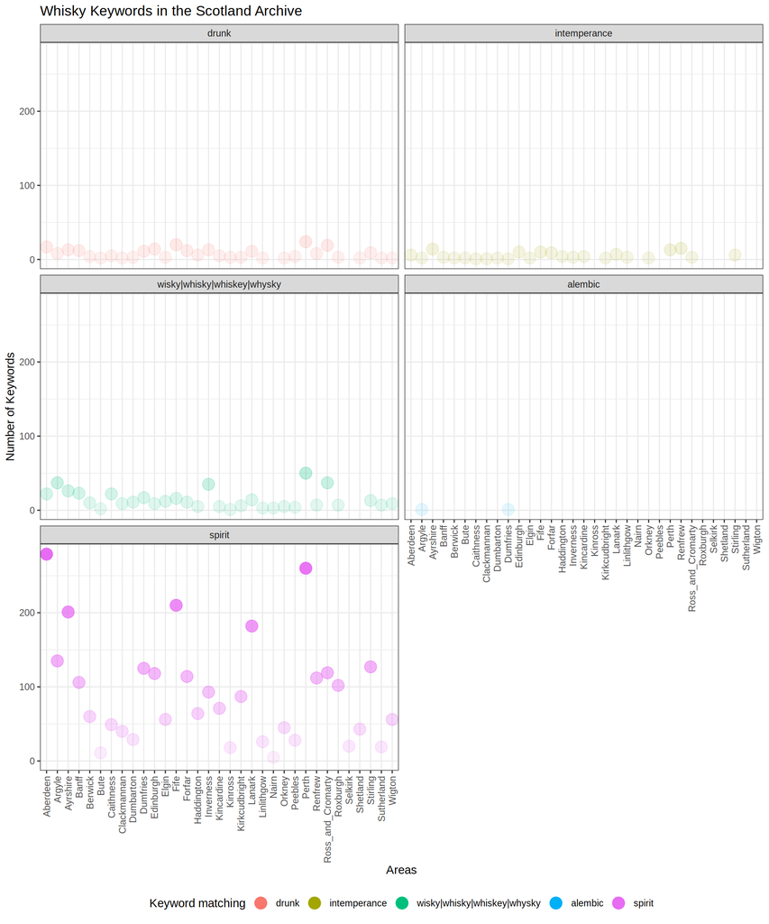

```r
ggplot(BreakoutWhisky, aes(x=Area, y=NMention, colour=pattern))+ # Select data set and coordinates we are going to plot
  geom_point(aes(alpha=NMention), size=5)+ # Which graph I want
  labs(x = "Areas", y = "Number of Keywords", colour = "Keyword matching", title="Whisky Keywords in the Scotland Archive")+ # Rename labs and title
  facet_wrap(~pattern, ncol=2)+
  theme_bw()+ # B/W Background
  theme(axis.text.x = element_text(angle = 90, vjust = 0.5, hjust = 1), legend.position = "bottom")+ # Rotate labels of x and move them slightly down. Plus move the position to the bottom
  guides(size = "none")+# Remove the Size from the Legend
  scale_alpha(guide = 'none') #Remove alpha from legend
```

Something is off…there are definitely more “spirit” than what I would expect let’s have a check

```r
spirits<-subset(Merged, keyword=="spirit")

spirits$NewText[1:10]
```

```
##  [1] "auchtermuchty useless spots cultivated within large plantation firs interspersed larix flourishing state property gourlay kilmarron gentlemen well known country enterprising spirit also judicious extensive improvements soil climate etc around town ground rather light loose black somewhat gr…
##  [2] "divisions commenced soon deposition gillispie surely among greatest judgements can befal place judgement temporally take away substance families support ministers thus often prevent just claims others paid judgement spiritually extinguish spirit love charity distinguishing characteristics h…
##  [3] "immediately must contribute prosperity town thereby number children present can service either parents find employment must also eligible situation woolen branch considering vicinity lomond hills frequent opportunities conveying wool ochils spirit industry enterprize now actuates inhabitant…
##  [4] "augmentation salary present can never expected man merit devote time talents trisle worthy remark youth place now ruined bad schoolmasters may attributed great degree narrow uncharitable dispositions inhabitants bigotry party spirit manifests actions given divisive courses rent tradesmen's …
##  [5] "rewarded farm coul islay given procured flounder probably stood much need many families highlands hold property consequence grants lords conveyed charters extremely short abundantly strong appear following specimen though divested spirit rhyme original donald chief macdonalds give castle"
##  [6] "farm acquired hill extent acres estimated rather superior quality land upon level tay probable improvements kind coming apace already stated respect produce manifest agriculture arrived advanced stage improvement active enterprizing spirit now beginning discover among farmers tenderly cheri…
##  [7] "state agriculture till lately old mode farming followed district viz taking crops oats bear alternately field three successive crops oats field letting remain long ley now better system agriculture introduced spirit industry promoted among tenants hence"
##  [8] "table weekly pensession's sum assessment poor sion medium first second third total 109 102 148 annual medium nearly table state appears number poor decreasing expence diminishing ascribed improving state increasing spirit industry among people linen manufacture affords employment old young …
##  [9] "unknown communicate water eastern runs aith western loch runs water luggar fish lochs pike eel hills minerals hills mountains though partly covered heath chiefly green abounding coarse species grass called spirit several volcanic appearances found stones basaltic species also figured stones…
## [10] "leading object converse dispute religious subjects church government concerning considerable diversity opinion amongst time shall softened keenness pertinacity generated diversity religious opinions shall rendered tolerant sorbearing towards differ wanting general spirit industry meliorate …
```

There is a problem: a spirit can be booze but can also refer to the holy spirit or the human spirit! For now, let’s just remove it from the pool but this is a clear example on where blank computational text analysis may fail

```r
Whisky2<-kwic(Report_tokens , #on what
             c("drunk","intemperance","wisky|whisky|whiskey|whysky", "alembic"), # Regex pattern
             valuetype = "regex",# use Regex to do so
             window = 30)

# Merge the two datasets
Merged3<-merge(Whisky2,TokenScotland, by.x="docname", by.y="ID")
# Merge the before and after the keyword
Merged3$NewTextWithKeyword<-paste(Merged3$pre,Merged3$keyword, Merged3$post)
Merged3$NewText<-paste(Merged3$pre, Merged3$Keyword, Merged3$post)
```

Now I want to see in which area of Scotland there are more instances of the keywords to see if anything has changed after removing “spirit.” I can do this by using pipes again:

```r
BreakoutWhisky2<- Merged3 %>%
  group_by(Area,pattern)%>%
  summarize(NMention=n())
```

And print it

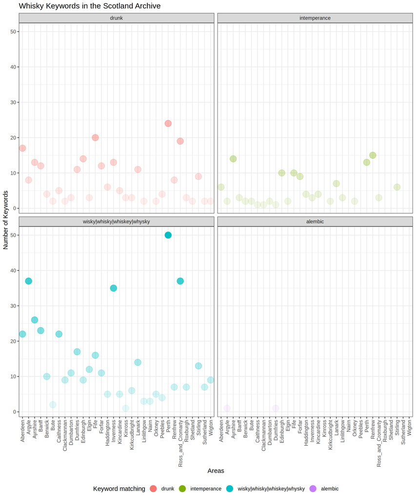

```r
ggplot(BreakoutWhisky2, aes(x=Area, y=NMention, colour=pattern))+ # Select data set and coordinates we are going to plot
  geom_point(aes(alpha=NMention), size=5)+ # Which graph I want
  labs(x = "Areas", y = "Number of Keywords", colour = "Keyword matching", title="Whisky Keywords in the Scotland Archive")+ # Rename labels and title
  facet_wrap(~pattern, ncol=2)+
  theme_bw()+ # B/W Background
  theme(axis.text.x = element_text(angle = 90, vjust = 0.5, hjust = 1), legend.position = "bottom")+ # Rotate labels of x and move them slightly down. Plus move the position to the bottom
  guides(size = "none")+# Remove the Size from the Legend
  scale_alpha(guide = 'none') #Remove alpha from legend
```

## Exercise 1:

Try to do the same with Witches related words

Here is a starting list for you but you can add more

c(“witch”, “spell”, “enchantment”,“magic”), # Regex pattern

```r
# Add here your solution. Tip: copy and paste the previous blocks and adapt the code
```

## Check what is around the keywords

Next step is to look at what is around our keywords. We will start by creating a new dataframe:

```r
Merged3$NewTextNoKeywords<-paste(Merged3$pre, Merged3$post)# Remove the keywords from the column we want to analyse (otherwise they would skew our wordcloud)
KWIC_tokens <- quanteda::tokens(Merged3$NewTextNoKeywords,
                                  remove_symbols=TRUE,
                                  remove_url=TRUE,
                                  remove_punct=TRUE,
                                  remove_numbers = FALSE,
                                  split_hyphens = TRUE)
```

Remove tokens under 3 characters. (Shorter words won’t tell us much about our data, and because we removed punctuation, we want to get rid of the truncated contractions–e.g. I’m –>‘I’, ‘m’)

```r
KWIC_tokens <- tokens_select(KWIC_tokens, min_nchar = 3)
```

Remove stop words

```r
KWIC_tokens <-tokens_remove(KWIC_tokens, c(stopwords("english"), "statistical", "account", "parish", "one", "years", "year"))
```

Create a DFM

```r
KWIC_dfm <- dfm(KWIC_tokens)
```

Make a word cloud of the results

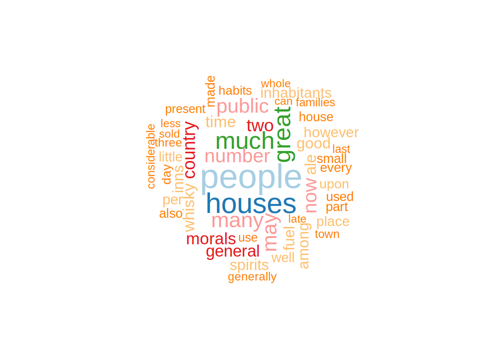

```r
textplot_wordcloud(KWIC_dfm , rotation = 0.25,
                   max_words=50,
                   color = rev(RColorBrewer::brewer.pal(10, "Paired")))
```

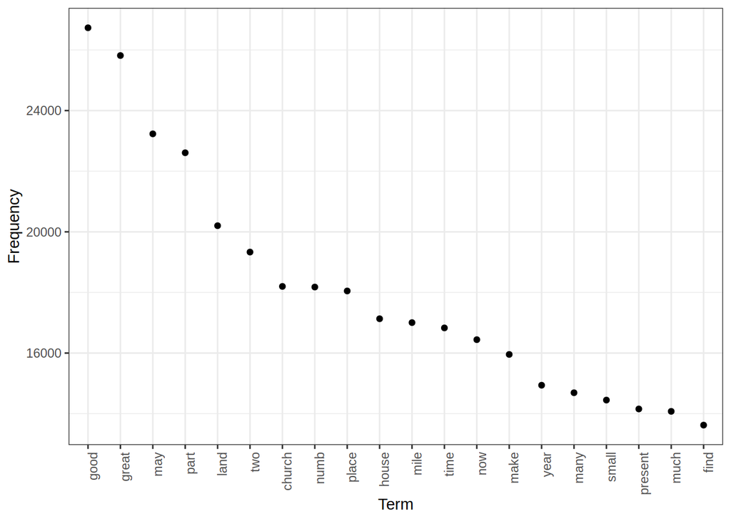

```r
top_keys2 <- topfeatures (KWIC_dfm, 20)
data.frame(list(term = names(top_keys), frequency = unname(top_keys))) %>% # Create a data.frame for ggplot
  ggplot(aes(x = reorder(term,-frequency), y = frequency)) + # Plotting with ggplot2
  geom_point() +
  theme_bw() +
  labs(x = "Term", y = "Frequency") +
  theme(axis.text.x=element_text(angle=90, hjust=1))
```

## Wrap-up activity: practice & table discussion

1. Subset the ‘Parish’ dataset by rows containing data about the Edinburgh area.(Hint: Edi_data <- subset(Parish, Area == ‘Edinburgh’))
2. Perform a keyword search on the Edinburgh data ‘text’ column for a keyword (or series of keywords) of your choice. (Don’t forget to tokenise the text first!)
3. Plot the keyword matches by ‘Parish,’ following the steps outlined in the lesson (performing the keyword search, merging the rows with a keyword match with the full dataset, using pipes to organise the data, and plotting with ggplot).
4. With your table, examine your plot. What does the visualisation show us about the topics related to your keyword(s) in the Edinburgh dataset? What do we still not know?
5. Thinking about the text analysis methods we practiced today, can you think of an example (perhaps from your research) of a use case for one of these methods?